# IE 582 HW 1

## Sude Yılmaz

[Link to my GitHub Repository](https://bu-ie-582.github.io/fall-24-sudeyilmaz/).

```r
# load necessary libraries
library(ggplot2)
library(factoextra)
library(caret)
library(patchwork)
```

# Data

```r
input_data <- read.csv("hw1_input.csv")
s11_real <- read.csv("hw1_real.csv")
s11_imag <- read.csv("hw1_img.csv")
```

```r
print("dimension of input data:")
dim(input_data)
print("dimension of S11 real part data:")
dim(s11_real)
print("dimension of S11 imaginary part data:")
dim(s11_imag)
```

```
[1] "dimension of input data:"
```

1. 385

2. 11

```
[1] "dimension of S11 real part data:"
```

1. 385

2. 201

```
[1] "dimension of S11 imaginary part data:"
```

1. 385

2. 201

### To understand the general structure of the data:

input_data seems to have all numeric attributes as desired for Principle Component Analysis

```r
str(input_data)
```

```
'data.frame':	385 obs. of  11 variables:
 $ length.of.patch                           : num  3.2 2.11 3.25 4.16 4.82 ...
 $ width.of.patch                            : num  2.29 2.9 4.82 2.29 2.95 ...
 $ height.of.patch                           : num  0.0125 0.0372 0.0254 0.0111 0.0197 ...
 $ height.of.substrate                       : num  0.139 0.149 0.579 0.117 0.164 ...
 $ height.of.solder.resist.layer             : num  0.0418 0.0568 0.03 0.0932 0.0943 ...
 $ radius.of.the.probe                       : num  0.0286 0.0289 0.0309 0.0176 0.0258 ...
 $ c_pad                                     : num  0.000549 0.005536 0.020274 0.001135 0.021725 ...
 $ c_antipad                                 : num  0.0324 0.0536 0.0498 0.0986 0.0728 ...
 $ c_probe                                   : num  0.3481 0.3264 0.4466 0.0557 0.2723 ...
 $ dielectric.constant.of.substrate          : num  3.74 4.93 4.77 4.1 2.53 ...
 $ dielectric.constant.of.solder.resist.layer: num  4.28 4.88 4.75 3.76 3.05 ...
```

```r
summary(input_data)
```

```
 length.of.patch width.of.patch  height.of.patch   height.of.substrate
 Min.   :1.806   Min.   :1.801   Min.   :0.01001   Min.   :0.1003
 1st Qu.:2.756   1st Qu.:2.501   1st Qu.:0.01619   1st Qu.:0.1269
 Median :3.638   Median :3.215   Median :0.02420   Median :0.1553
 Mean   :3.569   Mean   :3.537   Mean   :0.02427   Mean   :0.3476
 3rd Qu.:4.369   3rd Qu.:4.830   3rd Qu.:0.03169   3rd Qu.:0.6493
 Max.   :5.200   Max.   :5.199   Max.   :0.03984   Max.   :0.7991
 height.of.solder.resist.layer radius.of.the.probe     c_pad
 Min.   :0.02004               Min.   :0.01501     Min.   :3.143e-06
 1st Qu.:0.03869               1st Qu.:0.02339     1st Qu.:6.985e-03
 Median :0.06076               Median :0.03098     Median :1.245e-02
 Mean   :0.06007               Mean   :0.03220     Mean   :1.280e-02
 3rd Qu.:0.08025               3rd Qu.:0.04182     3rd Qu.:1.901e-02
 Max.   :0.09973               Max.   :0.04996     Max.   :2.500e-02
   c_antipad          c_probe        dielectric.constant.of.substrate
 Min.   :0.02529   Min.   :0.05081   Min.   :2.023
 1st Qu.:0.04201   1st Qu.:0.14857   1st Qu.:2.998
 Median :0.06053   Median :0.24505   Median :3.866
 Mean   :0.06065   Mean   :0.24559   Mean   :3.704
 3rd Qu.:0.07823   3rd Qu.:0.34020   3rd Qu.:4.376
 Max.   :0.09995   Max.   :0.44960   Max.   :4.999
 dielectric.constant.of.solder.resist.layer
 Min.   :2.002
 1st Qu.:2.784
 Median :3.481
 Mean   :3.522
 3rd Qu.:4.279
 Max.   :5.000
```

```r
head(input_data)
```

A data.frame: 6 × 11

|  | length.of.patch <dbl> | width.of.patch <dbl> | height.of.patch <dbl> | height.of.substrate <dbl> | height.of.solder.resist.layer <dbl> | radius.of.the.probe <dbl> | c_pad <dbl> | c_antipad <dbl> | c_probe <dbl> | dielectric.constant.of.substrate <dbl> | dielectric.constant.of.solder.resist.layer <dbl> |
| --- | --- | --- | --- | --- | --- | --- | --- | --- | --- | --- | --- |
| 1 | 3.202024 | 2.288742 | 0.01251361 | 0.1392470 | 0.04175706 | 0.02856645 | 0.0005490981 | 0.03240254 | 0.34814037 | 3.735926 | 4.278575 |
| 2 | 2.107848 | 2.895504 | 0.03717091 | 0.1494917 | 0.05677469 | 0.02892960 | 0.0055359917 | 0.05364651 | 0.32636872 | 4.929862 | 4.876068 |
| 3 | 3.252113 | 4.818411 | 0.02543177 | 0.5788343 | 0.02997204 | 0.03092160 | 0.0202741967 | 0.04984547 | 0.44663884 | 4.772670 | 4.745106 |
| 4 | 4.161509 | 2.294309 | 0.01105796 | 0.1172663 | 0.09322326 | 0.01760383 | 0.0011347265 | 0.09861046 | 0.05566543 | 4.102438 | 3.755671 |
| 5 | 4.820912 | 2.948325 | 0.01965842 | 0.1635031 | 0.09433670 | 0.02575722 | 0.0217250604 | 0.07281343 | 0.27228238 | 2.531031 | 3.047553 |
| 6 | 4.735663 | 2.767610 | 0.03688639 | 0.1130634 | 0.07834008 | 0.03286516 | 0.0116830052 | 0.03807039 | 0.38784164 | 2.065848 | 2.976976 |

```r
head(s11_real)
```

A data.frame: 6 × 201

|  | X0 <dbl> | X1 <dbl> | X2 <dbl> | X3 <dbl> | X4 <dbl> | X5 <dbl> | X6 <dbl> | X7 <dbl> | X8 <dbl> | X9 <dbl> | ⋯ | X191 <dbl> | X192 <dbl> | X193 <dbl> | X194 <dbl> | X195 <dbl> | X196 <dbl> | X197 <dbl> | X198 <dbl> | X199 <dbl> | X200 <dbl> |
| --- | --- | --- | --- | --- | --- | --- | --- | --- | --- | --- | --- | --- | --- | --- | --- | --- | --- | --- | --- | --- | --- |
| 1 | 0.6494714 | 0.6086228 | 0.5637705 | 0.5154846 | 0.4643651 | 0.4110217 | 0.3560556 | 0.3000436 | 0.2435250 | 0.1869921 | ⋯ | -0.8954507 | -0.89424988 | -0.89304453 | -0.89183468 | -0.89062034 | -0.88940154 | -0.88817829 | -0.88695060 | -0.88571850 | -0.88448200 |
| 2 | -0.6844430 | -0.6809262 | -0.6773545 | -0.6737266 | -0.6700410 | -0.6662963 | -0.6624911 | -0.6586236 | -0.6546923 | -0.6506955 | ⋯ | -0.8353030 | -0.83227607 | -0.82920948 | -0.82610522 | -0.82296512 | -0.81979089 | -0.81658409 | -0.81334618 | -0.81007849 | -0.80678224 |
| 3 | 0.6701945 | 0.6781830 | 0.6858858 | 0.6932941 | 0.7003990 | 0.7071913 | 0.7136613 | 0.7197992 | 0.7255947 | 0.7310370 | ⋯ | 0.6931709 | 0.67565284 | 0.65699238 | 0.63711279 | 0.61593570 | 0.59338351 | 0.56938284 | 0.54386959 | 0.51679585 | 0.48813927 |
| 4 | -0.8560263 | -0.8549622 | -0.8538917 | -0.8528148 | -0.8517314 | -0.8506416 | -0.8495452 | -0.8484423 | -0.8473327 | -0.8462166 | ⋯ | -0.1152051 | -0.09619706 | -0.07645588 | -0.05595287 | -0.03465993 | -0.01255003 | 0.01040214 | 0.03421932 | 0.05892074 | 0.08452087 |
| 5 | -0.9528760 | -0.9519012 | -0.9509061 | -0.9498921 | -0.9488601 | -0.9478115 | -0.9467471 | -0.9456679 | -0.9445749 | -0.9434689 | ⋯ | -0.6923487 | -0.69072022 | -0.68908819 | -0.68745259 | -0.68581340 | -0.68417063 | -0.68252427 | -0.68087433 | -0.67922080 | -0.67756368 |
| 6 | -0.8799115 | -0.8866439 | -0.8929797 | -0.8989429 | -0.9045559 | -0.9098395 | -0.9148132 | -0.9194953 | -0.9239028 | -0.9280517 | ⋯ | -0.8701834 | -0.86888216 | -0.86757287 | -0.86625542 | -0.86492974 | -0.86359573 | -0.86225331 | -0.86090241 | -0.85954293 | -0.85817478 |

```r
head(s11_imag)
```

A data.frame: 6 × 201

|  | X0 <dbl> | X1 <dbl> | X2 <dbl> | X3 <dbl> | X4 <dbl> | X5 <dbl> | X6 <dbl> | X7 <dbl> | X8 <dbl> | X9 <dbl> | ⋯ | X191 <dbl> | X192 <dbl> | X193 <dbl> | X194 <dbl> | X195 <dbl> | X196 <dbl> | X197 <dbl> | X198 <dbl> | X199 <dbl> | X200 <dbl> |
| --- | --- | --- | --- | --- | --- | --- | --- | --- | --- | --- | --- | --- | --- | --- | --- | --- | --- | --- | --- | --- | --- |
| 1 | -0.4351596 | -0.4933111 | -0.5473907 | -0.5970467 | -0.6420268 | -0.6821780 | -0.7174421 | -0.7478479 | -0.7735008 | -0.7945703 | ⋯ | 0.4187368 | 0.4213682 | 0.4239866 | 0.4265924 | 0.4291857 | 0.4317666 | 0.4343352 | 0.4368918 | 0.4394365 | 0.4419694 |
| 2 | 0.7109363 | 0.7140413 | 0.7171568 | 0.7202828 | 0.7234193 | 0.7265663 | 0.7297237 | 0.7328917 | 0.7360700 | 0.7392587 | ⋯ | 0.4420505 | 0.4494506 | 0.4567202 | 0.4638634 | 0.4708841 | 0.4777862 | 0.4845732 | 0.4912486 | 0.4978157 | 0.5042779 |
| 3 | 0.5498418 | 0.5379643 | 0.5258346 | 0.5134552 | 0.5008285 | 0.4879572 | 0.4748441 | 0.4614919 | 0.4479037 | 0.4340826 | ⋯ | -0.5185461 | -0.5342090 | -0.5495821 | -0.5645749 | -0.5790777 | -0.5929574 | -0.6060537 | -0.6181748 | -0.6290932 | -0.6385426 |
| 4 | 0.5073274 | 0.5090923 | 0.5108575 | 0.5126231 | 0.5143891 | 0.5161556 | 0.5179227 | 0.5196904 | 0.5214587 | 0.5232278 | ⋯ | 0.9285628 | 0.9277815 | 0.9264875 | 0.9246206 | 0.9221135 | 0.9188918 | 0.9148726 | 0.9099640 | 0.9040640 | 0.8970599 |
| 5 | 0.2495397 | 0.2541105 | 0.2586175 | 0.2630624 | 0.2674469 | 0.2717724 | 0.2760406 | 0.2802528 | 0.2844105 | 0.2885151 | ⋯ | 0.7055002 | 0.7070182 | 0.7085306 | 0.7100373 | 0.7115383 | 0.7130337 | 0.7145234 | 0.7160074 | 0.7174856 | 0.7189582 |
| 6 | -0.3843621 | -0.3714461 | -0.3587958 | -0.3464068 | -0.3342747 | -0.3223946 | -0.3107612 | -0.2993692 | -0.2882134 | -0.2772880 | ⋯ | 0.4741962 | 0.4765289 | 0.4788590 | 0.4811866 | 0.4835117 | 0.4858344 | 0.4881548 | 0.4904729 | 0.4927889 | 0.4951028 |

For S11 measures calculating the magnitude of data might bring beneficial insgihts as low magnitude values indicate a higher reflection. Therefore, magnitude data is stored in an additional data variable.

```r
s11_magnitude <- sqrt(s11_real^2 + s11_imag^2)
head(s11_magnitude)
```

A data.frame: 6 × 201

|  | X0 <dbl> | X1 <dbl> | X2 <dbl> | X3 <dbl> | X4 <dbl> | X5 <dbl> | X6 <dbl> | X7 <dbl> | X8 <dbl> | X9 <dbl> | ⋯ | X191 <dbl> | X192 <dbl> | X193 <dbl> | X194 <dbl> | X195 <dbl> | X196 <dbl> | X197 <dbl> | X198 <dbl> | X199 <dbl> | X200 <dbl> |
| --- | --- | --- | --- | --- | --- | --- | --- | --- | --- | --- | --- | --- | --- | --- | --- | --- | --- | --- | --- | --- | --- |
| 1 | 0.7817781 | 0.7834396 | 0.7857950 | 0.7887897 | 0.7923593 | 0.7964331 | 0.8009362 | 0.8057932 | 0.8109303 | 0.8162769 | ⋯ | 0.9885204 | 0.9885515 | 0.9885814 | 0.9886102 | 0.9886379 | 0.9886645 | 0.9886899 | 0.9887142 | 0.9887374 | 0.9887595 |
| 2 | 0.9868600 | 0.9866689 | 0.9864700 | 0.9862630 | 0.9860479 | 0.9858242 | 0.9855918 | 0.9853503 | 0.9850995 | 0.9848392 | ⋯ | 0.9450607 | 0.9458802 | 0.9466687 | 0.9474276 | 0.9481579 | 0.9488608 | 0.9495371 | 0.9501880 | 0.9508142 | 0.9514167 |
| 3 | 0.8668833 | 0.8656430 | 0.8642577 | 0.8627241 | 0.8610389 | 0.8591983 | 0.8571986 | 0.8550355 | 0.8527048 | 0.8502017 | ⋯ | 0.8656651 | 0.8613281 | 0.8565509 | 0.8512682 | 0.8454039 | 0.8388698 | 0.8315635 | 0.8233676 | 0.8141475 | 0.8037516 |
| 4 | 0.9950689 | 0.9950554 | 0.9950409 | 0.9950254 | 0.9950088 | 0.9949913 | 0.9949729 | 0.9949535 | 0.9949332 | 0.9949120 | ⋯ | 0.9356822 | 0.9327553 | 0.9296368 | 0.9263120 | 0.9227647 | 0.9189775 | 0.9149318 | 0.9106072 | 0.9059820 | 0.9010329 |
| 5 | 0.9850090 | 0.9852350 | 0.9854469 | 0.9856454 | 0.9858313 | 0.9860055 | 0.9861685 | 0.9863211 | 0.9864639 | 0.9865975 | ⋯ | 0.9884722 | 0.9884175 | 0.9883613 | 0.9883036 | 0.9882443 | 0.9881834 | 0.9881210 | 0.9880569 | 0.9879912 | 0.9879238 |
| 6 | 0.9601971 | 0.9613062 | 0.9623654 | 0.9633774 | 0.9643448 | 0.9652700 | 0.9661551 | 0.9670023 | 0.9678137 | 0.9685910 | ⋯ | 0.9910001 | 0.9909773 | 0.9909534 | 0.9909283 | 0.9909021 | 0.9908747 | 0.9908460 | 0.9908162 | 0.9907850 | 0.9907526 |

To visualize magnitude values for different frequencies, first 10 samples of the data is plotted:

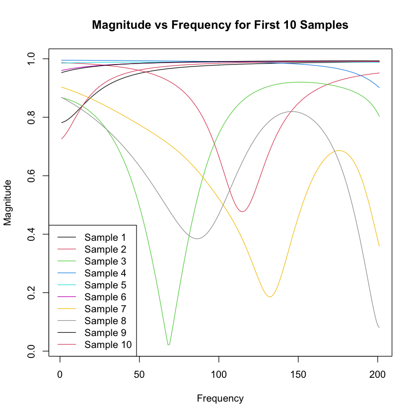

```r
# plot the magnitudes of outputs with respect to frequenciens for the first 10 data:

frequency <- seq(1, ncol(s11_magnitude), length.out = ncol(s11_magnitude))
matplot(frequency, t(s11_magnitude[1:10, ]), type = "l", lty = 1, col = 1:10,
        xlab = "Frequency", ylab = "Magnitude", main = "Magnitude vs Frequency for First 10 Samples")
legend("bottomleft", legend = paste("Sample", 1:10), col = 1:10, lty = 1)
```

# Principle Component Analysis

First, since the output data has too many attributes, meaning too many number of frequency values that magnitude output is measured for, to simplfy the process a dimensionality reduction should be applied. Principle component analysis is applied to the output data for reducing the number of attributes required to understand the data. This has done by appling PCA for magnitude of S11, real part of S11 and imaginary part of S11 seperatly in the following parts.

# PCA for Output Data

## 1) PCA for Magnitude of S11

First of all PCA is applied to the magnitude of S11 with following command.

```r
# apply pca for s11 magnitude
s11_magnitude_pca <- prcomp(s11_magnitude, scale = TRUE)
summary(s11_magnitude_pca)
```

```
Importance of components:
                           PC1    PC2    PC3    PC4     PC5     PC6     PC7
Standard deviation     10.9830 4.9576 4.7828 3.8827 2.31984 1.98264 1.63903
Proportion of Variance  0.6001 0.1223 0.1138 0.0750 0.02677 0.01956 0.01337
Cumulative Proportion   0.6001 0.7224 0.8362 0.9112 0.93800 0.95755 0.97092
                           PC8     PC9    PC10    PC11   PC12    PC13    PC14
Standard deviation     1.25367 0.99874 0.86574 0.77215 0.6490 0.50064 0.47396
Proportion of Variance 0.00782 0.00496 0.00373 0.00297 0.0021 0.00125 0.00112
Cumulative Proportion  0.97874 0.98370 0.98743 0.99040 0.9925 0.99374 0.99486
                         PC15    PC16    PC17    PC18    PC19    PC20   PC21
Standard deviation     0.4016 0.37374 0.34943 0.32272 0.30262 0.25355 0.2451
Proportion of Variance 0.0008 0.00069 0.00061 0.00052 0.00046 0.00032 0.0003
Cumulative Proportion  0.9957 0.99635 0.99696 0.99748 0.99793 0.99825 0.9986
                         PC22    PC23    PC24    PC25    PC26    PC27    PC28
Standard deviation     0.2022 0.18537 0.16947 0.15660 0.15026 0.14554 0.13801
Proportion of Variance 0.0002 0.00017 0.00014 0.00012 0.00011 0.00011 0.00009
Cumulative Proportion  0.9988 0.99893 0.99907 0.99919 0.99930 0.99941 0.99950
                          PC29    PC30    PC31    PC32    PC33    PC34    PC35
Standard deviation     0.13650 0.12540 0.10908 0.09209 0.09069 0.07036 0.06658
Proportion of Variance 0.00009 0.00008 0.00006 0.00004 0.00004 0.00002 0.00002
Cumulative Proportion  0.99960 0.99968 0.99973 0.99978 0.99982 0.99984 0.99986
                          PC36    PC37    PC38    PC39    PC40    PC41    PC42
Standard deviation     0.06312 0.06122 0.05659 0.05069 0.04902 0.04552 0.03843
Proportion of Variance 0.00002 0.00002 0.00002 0.00001 0.00001 0.00001 0.00001
Cumulative Proportion  0.99988 0.99990 0.99992 0.99993 0.99994 0.99995 0.99996
                          PC43    PC44    PC45    PC46    PC47    PC48   PC49
Standard deviation     0.03667 0.03443 0.02917 0.02671 0.02253 0.01928 0.0179
Proportion of Variance 0.00001 0.00001 0.00000 0.00000 0.00000 0.00000 0.0000
Cumulative Proportion  0.99997 0.99997 0.99998 0.99998 0.99998 0.99999 1.0000
                          PC50    PC51    PC52    PC53    PC54    PC55    PC56
Standard deviation     0.01643 0.01569 0.01557 0.01403 0.01337 0.01198 0.01128
Proportion of Variance 0.00000 0.00000 0.00000 0.00000 0.00000 0.00000 0.00000
Cumulative Proportion  0.99999 0.99999 0.99999 0.99999 0.99999 0.99999 0.99999
                          PC57    PC58     PC59     PC60    PC61    PC62
Standard deviation     0.01071 0.01062 0.009703 0.009491 0.00915 0.00873
Proportion of Variance 0.00000 0.00000 0.000000 0.000000 0.00000 0.00000
Cumulative Proportion  1.00000 1.00000 1.000000 1.000000 1.00000 1.00000
                           PC63     PC64     PC65    PC66     PC67    PC68
Standard deviation     0.007706 0.007309 0.007029 0.00614 0.005757 0.00527
Proportion of Variance 0.000000 0.000000 0.000000 0.00000 0.000000 0.00000
```

[output cut: 90 more lines]

```
Standard deviation     1.044e-09 3.596e-10 3.01e-10 2.653e-10 2.309e-10
Proportion of Variance 0.000e+00 0.000e+00 0.00e+00 0.000e+00 0.000e+00
Cumulative Proportion  1.000e+00 1.000e+00 1.00e+00 1.000e+00 1.000e+00
                           PC189     PC190     PC191     PC192     PC193
Standard deviation     1.576e-10 8.253e-11 5.638e-11 5.318e-11 3.593e-11
Proportion of Variance 0.000e+00 0.000e+00 0.000e+00 0.000e+00 0.000e+00
Cumulative Proportion  1.000e+00 1.000e+00 1.000e+00 1.000e+00 1.000e+00
                           PC194     PC195     PC196     PC197     PC198
Standard deviation     1.844e-11 6.528e-12 3.314e-12 2.061e-13 6.806e-14
Proportion of Variance 0.000e+00 0.000e+00 0.000e+00 0.000e+00 0.000e+00
Cumulative Proportion  1.000e+00 1.000e+00 1.000e+00 1.000e+00 1.000e+00
                          PC199     PC200     PC201
Standard deviation     2.96e-14 1.652e-14 4.877e-15
Proportion of Variance 0.00e+00 0.000e+00 0.000e+00
Cumulative Proportion  1.00e+00 1.000e+00 1.000e+00
```

The above results show that with only PC1 it is possible to explain 60% of the variance of the data. Which is a good result that shows most of the variance of the data can be explained with PC1.

Then, to see visually how much variance is explained by each principle component scree plot is plotted:

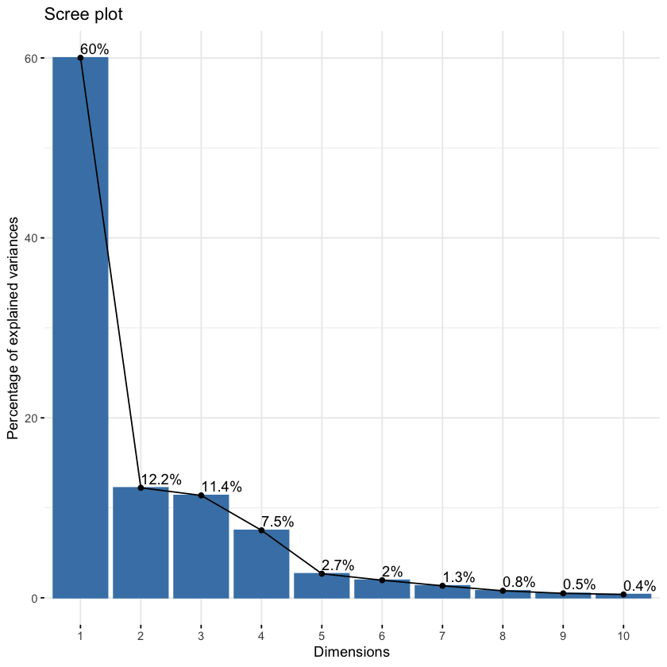

```r
# scree plot of variance
fviz_eig(s11_magnitude_pca,
        addlabels=TRUE)
```

The above plot shows that there is a significant different between PC1 and other principle components in explaining the variance within the data. When we use both PC1 and PC2 the explained variance increases to 72.2%, which can also be preferred for later measurements. However, PC1 alone is already a good component to express the data.

And the below biplot shows the relationship between the observations and the original variables in a reduced-dimensional space. It shows how observations (data points) are positioned relative to the variables (arrows), highlighting correlations and variance explanations in the data.

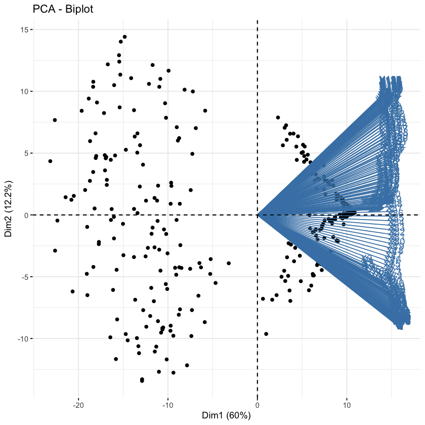

```r
# biplot with labeled variables
fviz_pca_biplot(s11_magnitude_pca,
               label = "var")
```

## 2) PCA for Real Part of S11

Then, PCA is applied to the real part of the S11 with following command.

```r
# apply pca for s11 real part
s11_real_pca <- prcomp(s11_real, scale = TRUE)
summary(s11_real_pca)
```

```
Importance of components:
                           PC1     PC2    PC3     PC4     PC5     PC6     PC7
Standard deviation     13.0873 3.28788 3.0207 2.18889 1.43098 1.03540 0.85225
Proportion of Variance  0.8521 0.05378 0.0454 0.02384 0.01019 0.00533 0.00361
Cumulative Proportion   0.8521 0.90591 0.9513 0.97514 0.98533 0.99067 0.99428
                          PC8     PC9    PC10    PC11    PC12    PC13    PC14
Standard deviation     0.6011 0.45704 0.41981 0.35517 0.27661 0.22834 0.18698
Proportion of Variance 0.0018 0.00104 0.00088 0.00063 0.00038 0.00026 0.00017
Cumulative Proportion  0.9961 0.99712 0.99799 0.99862 0.99900 0.99926 0.99943
                          PC15   PC16    PC17    PC18    PC19    PC20    PC21
Standard deviation     0.14643 0.1390 0.13321 0.10578 0.10488 0.07980 0.07055
Proportion of Variance 0.00011 0.0001 0.00009 0.00006 0.00005 0.00003 0.00002
Cumulative Proportion  0.99954 0.9996 0.99973 0.99978 0.99984 0.99987 0.99989
                          PC22    PC23    PC24    PC25    PC26    PC27    PC28
Standard deviation     0.06596 0.05257 0.04998 0.04711 0.04311 0.03829 0.03764
Proportion of Variance 0.00002 0.00001 0.00001 0.00001 0.00001 0.00001 0.00001
Cumulative Proportion  0.99991 0.99993 0.99994 0.99995 0.99996 0.99997 0.99997
                          PC29    PC30    PC31   PC32  PC33    PC34    PC35
Standard deviation     0.03420 0.03191 0.02498 0.0211 0.019 0.01884 0.01861
Proportion of Variance 0.00001 0.00001 0.00000 0.0000 0.000 0.00000 0.00000
Cumulative Proportion  0.99998 0.99999 0.99999 1.0000 1.000 0.99999 1.00000
                          PC36    PC37    PC38    PC39     PC40    PC41
Standard deviation     0.01354 0.01127 0.01106 0.01067 0.008108 0.00798
Proportion of Variance 0.00000 0.00000 0.00000 0.00000 0.000000 0.00000
Cumulative Proportion  1.00000 1.00000 1.00000 1.00000 1.000000 1.00000
                           PC42     PC43     PC44     PC45     PC46     PC47
Standard deviation     0.007106 0.004561 0.004199 0.003759 0.003569 0.003261
Proportion of Variance 0.000000 0.000000 0.000000 0.000000 0.000000 0.000000
Cumulative Proportion  1.000000 1.000000 1.000000 1.000000 1.000000 1.000000
                           PC48     PC49     PC50    PC51     PC52     PC53
Standard deviation     0.002425 0.002385 0.002104 0.00164 0.001528 0.001328
Proportion of Variance 0.000000 0.000000 0.000000 0.00000 0.000000 0.000000
Cumulative Proportion  1.000000 1.000000 1.000000 1.00000 1.000000 1.000000
                          PC54     PC55     PC56     PC57      PC58      PC59
Standard deviation     0.00132 0.001244 0.001183 0.001126 0.0007053 0.0006968
Proportion of Variance 0.00000 0.000000 0.000000 0.000000 0.0000000 0.0000000
Cumulative Proportion  1.00000 1.000000 1.000000 1.000000 1.0000000 1.0000000
                            PC60      PC61      PC62      PC63      PC64
Standard deviation     0.0005502 0.0005058 0.0005006 0.0003718 0.0002968
Proportion of Variance 0.0000000 0.0000000 0.0000000 0.0000000 0.0000000
```

[output cut: 94 more lines]

```
Standard deviation     1.195e-15 1.195e-15 1.195e-15 1.195e-15 1.195e-15
Proportion of Variance 0.000e+00 0.000e+00 0.000e+00 0.000e+00 0.000e+00
Cumulative Proportion  1.000e+00 1.000e+00 1.000e+00 1.000e+00 1.000e+00
                           PC187     PC188     PC189     PC190     PC191
Standard deviation     1.195e-15 1.195e-15 1.195e-15 1.195e-15 1.195e-15
Proportion of Variance 0.000e+00 0.000e+00 0.000e+00 0.000e+00 0.000e+00
Cumulative Proportion  1.000e+00 1.000e+00 1.000e+00 1.000e+00 1.000e+00
                           PC192     PC193     PC194     PC195     PC196
Standard deviation     1.195e-15 1.195e-15 1.195e-15 1.195e-15 1.195e-15
Proportion of Variance 0.000e+00 0.000e+00 0.000e+00 0.000e+00 0.000e+00
Cumulative Proportion  1.000e+00 1.000e+00 1.000e+00 1.000e+00 1.000e+00
                           PC197     PC198     PC199     PC200     PC201
Standard deviation     1.195e-15 1.195e-15 1.089e-15 8.014e-16 4.418e-16
Proportion of Variance 0.000e+00 0.000e+00 0.000e+00 0.000e+00 0.000e+00
Cumulative Proportion  1.000e+00 1.000e+00 1.000e+00 1.000e+00 1.000e+00
```

The above results show that with only PC1 it is possible to explain 85% of the variance of the data. This is a really good results showing that PC1 is solely enough to explain almost all of the variance of the data.

Then, to see visually how much variance is explained by each principle component scree plot is plotted:

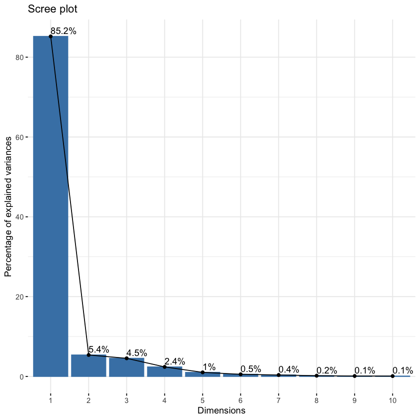

```r
# scree plot of variance
fviz_eig(s11_real_pca,
        addlabels=TRUE)
```

Again the above plot shows that PC1 is significantly better in terms of explaining the variance in the data than the other components. The second best component, PC2, can only explain 5.4% of the variance indicating ony using PC1 is good enough both for explaining variance moslty and also allowing simplicity by only selecting one component.

And then again below biplot is plotted. Contrast to the previous biplot, in the plot the arrows on the left side. This result indicates that for the real part of the S11, there is a negative correlation with the PC1.

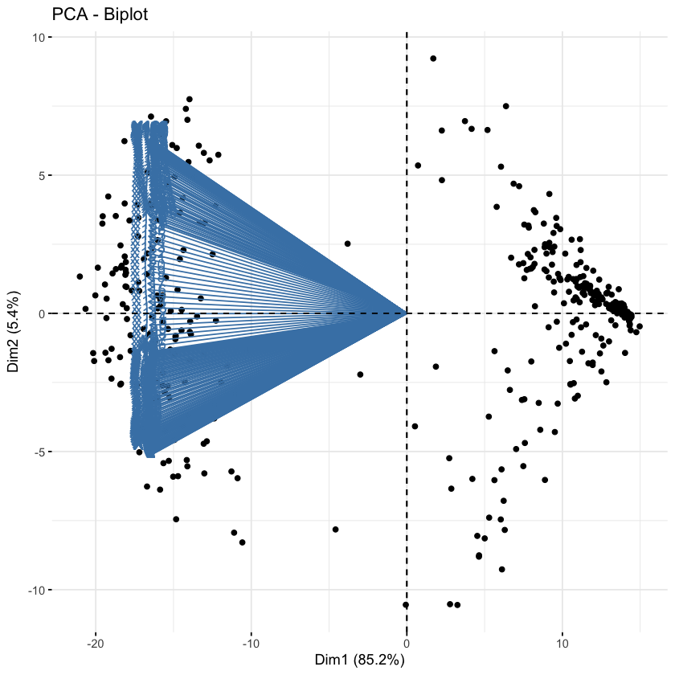

```r
# biplot with labeled variables
fviz_pca_biplot(s11_real_pca,
               label = "var")
```

## 3) PCA for Imaginary Part of S11

Then, PCA is applied to the imaginary part of the S11 with following command.

```r
# apply pca for s11 imaginary part
s11_imag_pca <- prcomp(s11_imag, scale = TRUE)
summary(s11_imag_pca)
```

```
Importance of components:
                          PC1    PC2    PC3    PC4     PC5    PC6     PC7
Standard deviation     9.1524 6.7547 5.7051 4.5522 2.75745 1.9645 1.52438
Proportion of Variance 0.4167 0.2270 0.1619 0.1031 0.03783 0.0192 0.01156
Cumulative Proportion  0.4167 0.6437 0.8057 0.9088 0.94659 0.9658 0.97735
                           PC8     PC9    PC10    PC11    PC12    PC13    PC14
Standard deviation     1.22859 1.01791 0.71404 0.62857 0.50225 0.45858 0.36862
Proportion of Variance 0.00751 0.00515 0.00254 0.00197 0.00126 0.00105 0.00068
Cumulative Proportion  0.98486 0.99002 0.99256 0.99452 0.99578 0.99682 0.99750
                          PC15    PC16    PC17    PC18   PC19    PC20    PC21
Standard deviation     0.35858 0.27377 0.25759 0.23320 0.1985 0.18882 0.15594
Proportion of Variance 0.00064 0.00037 0.00033 0.00027 0.0002 0.00018 0.00012
Cumulative Proportion  0.99814 0.99851 0.99884 0.99911 0.9993 0.99949 0.99961
                          PC22    PC23    PC24    PC25    PC26    PC27    PC28
Standard deviation     0.12452 0.10401 0.09598 0.08946 0.07864 0.07389 0.07149
Proportion of Variance 0.00008 0.00005 0.00005 0.00004 0.00003 0.00003 0.00003
Cumulative Proportion  0.99968 0.99974 0.99978 0.99982 0.99985 0.99988 0.99991
                          PC29    PC30    PC31    PC32    PC33    PC34    PC35
Standard deviation     0.06928 0.05768 0.04733 0.04509 0.03712 0.03368 0.02583
Proportion of Variance 0.00002 0.00002 0.00001 0.00001 0.00001 0.00001 0.00000
Cumulative Proportion  0.99993 0.99995 0.99996 0.99997 0.99998 0.99998 0.99998
                          PC36    PC37    PC38    PC39    PC40    PC41    PC42
Standard deviation     0.02249 0.02201 0.01988 0.01867 0.01789 0.01603 0.01481
Proportion of Variance 0.00000 0.00000 0.00000 0.00000 0.00000 0.00000 0.00000
Cumulative Proportion  0.99999 0.99999 0.99999 0.99999 0.99999 1.00000 1.00000
                         PC43    PC44     PC45    PC46     PC47     PC48
Standard deviation     0.0145 0.01142 0.008907 0.00808 0.007581 0.006475
Proportion of Variance 0.0000 0.00000 0.000000 0.00000 0.000000 0.000000
Cumulative Proportion  1.0000 1.00000 1.000000 1.00000 1.000000 1.000000
                           PC49     PC50    PC51     PC52     PC53     PC54
Standard deviation     0.004803 0.004357 0.00388 0.003481 0.002898 0.002681
Proportion of Variance 0.000000 0.000000 0.00000 0.000000 0.000000 0.000000
Cumulative Proportion  1.000000 1.000000 1.00000 1.000000 1.000000 1.000000
                           PC55    PC56     PC57    PC58     PC59    PC60
Standard deviation     0.002474 0.00244 0.001407 0.00137 0.001248 0.00108
Proportion of Variance 0.000000 0.00000 0.000000 0.00000 0.000000 0.00000
Cumulative Proportion  1.000000 1.00000 1.000000 1.00000 1.000000 1.00000
                            PC61      PC62      PC63      PC64     PC65
Standard deviation     0.0009888 0.0007498 0.0006184 0.0005282 0.000462
Proportion of Variance 0.0000000 0.0000000 0.0000000 0.0000000 0.000000
```

[output cut: 94 more lines]

```
Standard deviation     7.425e-16 7.423e-16 7.399e-16 7.293e-16 7.223e-16
Proportion of Variance 0.000e+00 0.000e+00 0.000e+00 0.000e+00 0.000e+00
Cumulative Proportion  1.000e+00 1.000e+00 1.000e+00 1.000e+00 1.000e+00
                           PC188     PC189     PC190     PC191     PC192
Standard deviation     7.202e-16 7.168e-16 7.161e-16 6.986e-16 6.959e-16
Proportion of Variance 0.000e+00 0.000e+00 0.000e+00 0.000e+00 0.000e+00
Cumulative Proportion  1.000e+00 1.000e+00 1.000e+00 1.000e+00 1.000e+00
                           PC193     PC194     PC195     PC196     PC197
Standard deviation     6.943e-16 6.568e-16 6.541e-16 6.493e-16 6.441e-16
Proportion of Variance 0.000e+00 0.000e+00 0.000e+00 0.000e+00 0.000e+00
Cumulative Proportion  1.000e+00 1.000e+00 1.000e+00 1.000e+00 1.000e+00
                           PC198     PC199     PC200     PC201
Standard deviation     6.168e-16 6.126e-16 4.955e-16 4.284e-16
Proportion of Variance 0.000e+00 0.000e+00 0.000e+00 0.000e+00
Cumulative Proportion  1.000e+00 1.000e+00 1.000e+00 1.000e+00
```

The above results show that now PC1 can explain 41.6% of the variance of the data. This result is a bit worse than the results of magnitude PC1, and real part PC1, but still PC1 can explain almost half of the variance.

Then, to see visually how much variance is explained by each principle component scree plot is plotted:

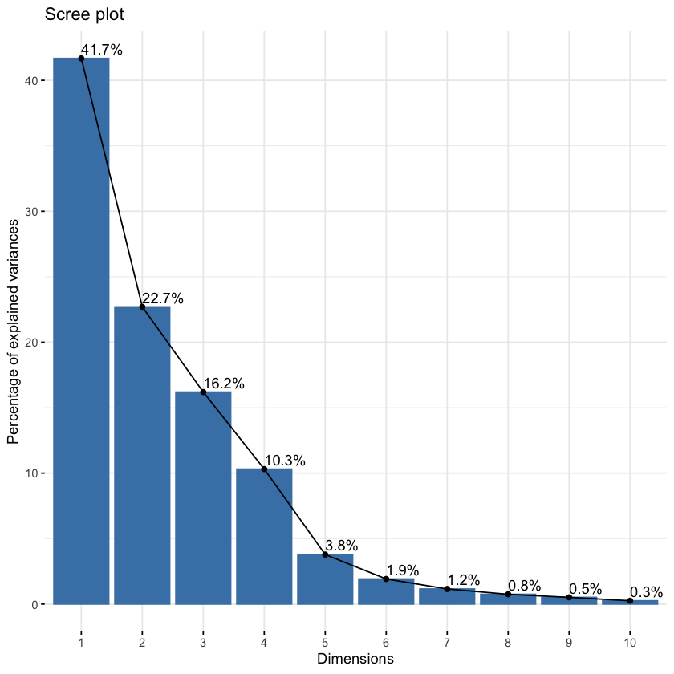

```r
# scree plot of variance
fviz_eig(s11_imag_pca,
        addlabels=TRUE)
```

So, for this case above plot shows that there is less dramatic difference between PC1 and PC2.

And the below biplot shows the positive correlation between imaginary part and PC1. It also shows that now the arrows less densed than in previous biplots. This might indicate the decrease in explaining variance.

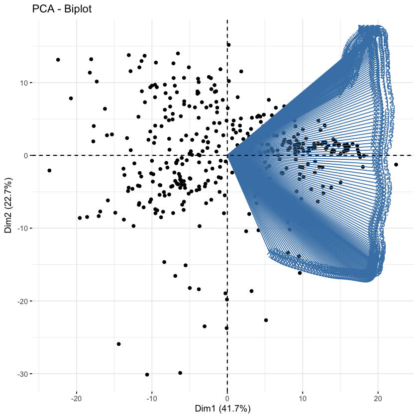

```r
# biplot with labeled variables
fviz_pca_biplot(s11_imag_pca,
               label = "var")
```

# PCA for Input Data

Then, since input data has 11 different attributes to reduce the number of components PCA is also applied for the input_data to simplfy the process.

```r
input_data_pca <- prcomp(input_data, scale = TRUE)
summary(input_data_pca)
```

```
Importance of components:
                          PC1    PC2    PC3     PC4     PC5     PC6     PC7
Standard deviation     1.5095 1.1035 1.0490 1.02801 1.00528 0.98643 0.97070
Proportion of Variance 0.2072 0.1107 0.1000 0.09607 0.09187 0.08846 0.08566
Cumulative Proportion  0.2072 0.3179 0.4179 0.51397 0.60584 0.69430 0.77996
                           PC8    PC9   PC10    PC11
Standard deviation     0.94771 0.8985 0.8008 0.27132
Proportion of Variance 0.08165 0.0734 0.0583 0.00669
Cumulative Proportion  0.86161 0.9350 0.9933 1.00000
```

Accordingly, PC1 can explain only 20.7% of the variance of the data. This is not a good result as previous ones but here the more important measure is that how much PC1 can explain the outputs.

First, again to see visually how much variance is explained by each principle component scree plot is plotted:

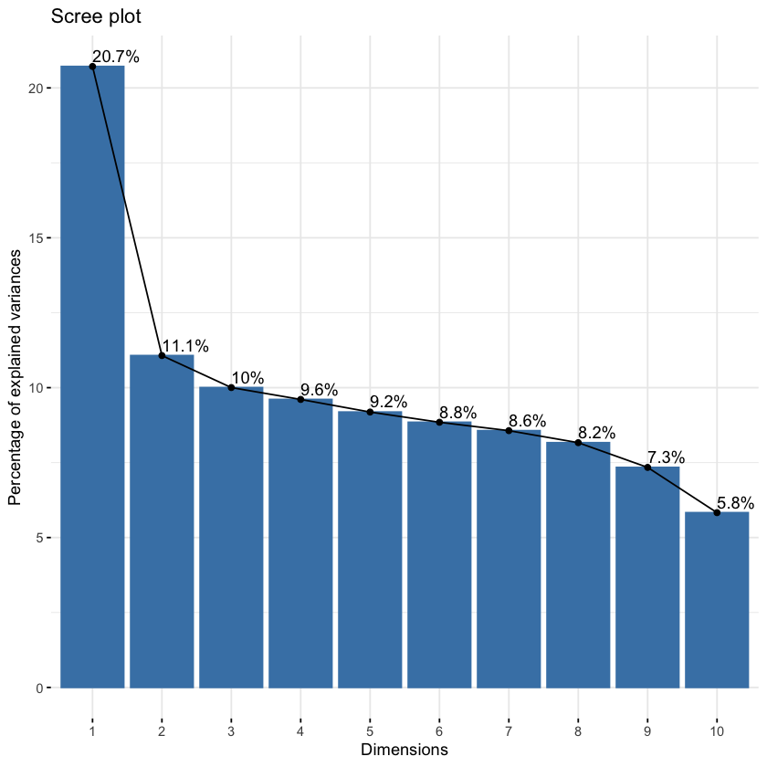

```r
# scree plot of variance
fviz_eig(input_data_pca,
        addlabels=TRUE)
```

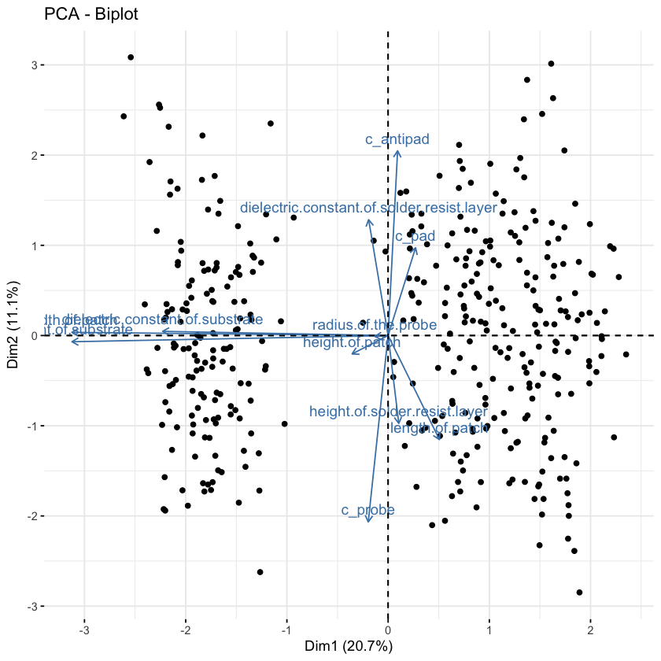

```r
# biplot with default settings
fviz_pca_biplot(input_data_pca,
               label = "var")
```

### Understanding How Good Can the Principle Components of Input Data Explain Output Data:

### Correlation Between Input Data and Real Part of Output Data:

In order to understand that the correlation between each principle component of input_data and each principle component of s11_real, a correlation matrix is generated and each pair having correlation above 0.8 is printed below.

```r
# extract scores from the PCA results
input_scores <- input_data_pca$x
output_scores_real <- s11_real_pca$x

# calculate correlations between all pairs of PCs
num_input_pcs <- ncol(input_scores)
num_output_pcs <- ncol(output_scores_real)
cor_matrix <- matrix(NA, nrow = num_input_pcs, ncol = num_output_pcs,
                     dimnames = list(paste0("Input_PC", 1:num_input_pcs),
                                     paste0("Real_Output_PC", 1:num_output_pcs)))

# fill the matrix with correlations
for (i in 1:num_input_pcs) {
  for (j in 1:num_output_pcs) {
    cor_matrix[i, j] <- cor(input_scores[, i], output_scores_real[, j])
  }
}

# pairs with high correlations treshold = 0.8
high_cor_pairs <- which(abs(cor_matrix) > 0.8, arr.ind = TRUE)

# display high-correlation pairs with their correlation values
if (nrow(high_cor_pairs) > 0) {
  for (k in 1:nrow(high_cor_pairs)) {
    input_pc <- high_cor_pairs[k, 1]
    output_pc <- high_cor_pairs[k, 2]
    correlation_value <- cor_matrix[input_pc, output_pc]
    cat(sprintf("Input_PC%d and Real_Output_PC%d have a high correlation of %.2f\n",
                input_pc, output_pc, correlation_value))
  }
} else {
  cat("No pairs with high correlation found.\n")
}
```

```
Input_PC1 and Real_Output_PC1 have a high correlation of 0.92
```

The above result shows that there is only "high correlation" between PC1 of Input Data and PC1 of real part of output data. Since previously, we showed that PC1 for real part of output data is good to explain the variance between data and now we can see the high correlation between PC1 of input data with that output data, we can conclude that PC1 of input data can explain the real part of output data very well.

### Correlation Between Input Data and Imaginary Part of Output Data:

In order to understand that the correlation between each principle component of input_data and each principle component of s11_imag, a correlation matrix is generated and each pair having correlation above 0.5 is printed below. Now, the treshold is selected a bit lower because higher tresholds did not result in with any "high correlation"s.

```r
# extract scores from the PCA results
input_scores <- input_data_pca$x
output_scores_imag <- s11_imag_pca$x

# calculate correlations between all pairs of PCs
num_input_pcs <- ncol(input_scores)
num_output_pcs <- ncol(output_scores_imag)
cor_matrix <- matrix(NA, nrow = num_input_pcs, ncol = num_output_pcs,
                     dimnames = list(paste0("Input_PC", 1:num_input_pcs),
                                     paste0("Imaginary_Output_PC", 1:num_output_pcs)))

# fill the matrix with correlations
for (i in 1:num_input_pcs) {
  for (j in 1:num_output_pcs) {
    cor_matrix[i, j] <- cor(input_scores[, i], output_scores_imag[, j])
  }
}

# pairs with high correlations treshold = 0.5
high_cor_pairs <- which(abs(cor_matrix) > 0.5, arr.ind = TRUE)

# display high-correlation pairs with their correlation values
if (nrow(high_cor_pairs) > 0) {
  for (k in 1:nrow(high_cor_pairs)) {
    input_pc <- high_cor_pairs[k, 1]
    output_pc <- high_cor_pairs[k, 2]
    correlation_value <- cor_matrix[input_pc, output_pc]
    cat(sprintf("Input_PC%d and Imaginary_Output_PC%d have a high correlation of %.2f\n",
                input_pc, output_pc, correlation_value))
  }
} else {
  cat("No pairs with high correlation found.\n")
}
```

```
Input_PC1 and Imaginary_Output_PC1 have a high correlation of 0.53
```

The above result shows that there is only "high correlation" between PC1 of Input Data and PC1 of imaginary part of output data. Since previously, we showed that PC1 for imaginary part of output data can explain almost 40% of the variance between data and now we can see the almost high correlation between PC1 of input data with that output data, we can conclude that PC1 of input data can almost mostly explain the imaginary part of output data.

### Correlation Between Input Data and Magnitude of Output Data:

In order to understand that the correlation between each principle component of input_data and each principle component of s11_magnitude, a correlation matrix is generated and each pair having correlation above 0.3 is printed below. Even selecting this much of a low treshold resulted in with only 1 high correlation.

```r
# extract scores from the PCA results
input_scores <- input_data_pca$x
output_scores_magnitude <- s11_magnitude_pca$x

# calculate correlations between all pairs of PCs
num_input_pcs <- ncol(input_scores)
num_output_pcs <- ncol(output_scores_magnitude)
cor_matrix <- matrix(NA, nrow = num_input_pcs, ncol = num_output_pcs,
                     dimnames = list(paste0("Input_PC", 1:num_input_pcs),
                                     paste0("Magnitude_Output_PC", 1:num_output_pcs)))

# fill the matrix with correlations
for (i in 1:num_input_pcs) {
  for (j in 1:num_output_pcs) {
    cor_matrix[i, j] <- cor(input_scores[, i], output_scores_magnitude[, j])
  }
}

# pairs with high correlations treshold = 0.3
high_cor_pairs <- which(abs(cor_matrix) > 0.3, arr.ind = TRUE)

# display high-correlation pairs with their correlation values
if (nrow(high_cor_pairs) > 0) {
  for (k in 1:nrow(high_cor_pairs)) {
    input_pc <- high_cor_pairs[k, 1]
    output_pc <- high_cor_pairs[k, 2]
    correlation_value <- cor_matrix[input_pc, output_pc]
    cat(sprintf("Input_PC%d and Magnitude_Output_PC%d have a high correlation of %.2f\n",
                input_pc, output_pc, correlation_value))
  }
} else {
  cat("No pairs with high correlation found.\n")
}
```

```
Input_PC1 and Magnitude_Output_PC1 have a high correlation of 0.92
```

The above result shows that there is only "high correlation" between PC1 of Input Data and PC1 of magnitude of output data even when the treshold is low. Since previously, we showed that PC1 for magnitude of output data can explain almost 60% of the variance between data and now we can see the very high correlation between PC1 of input data with that output data, we can conclude that PC1 of input data can explain the magnitude of output data very well.

# Plots for PC1 of Input vs PC1 of Outputs

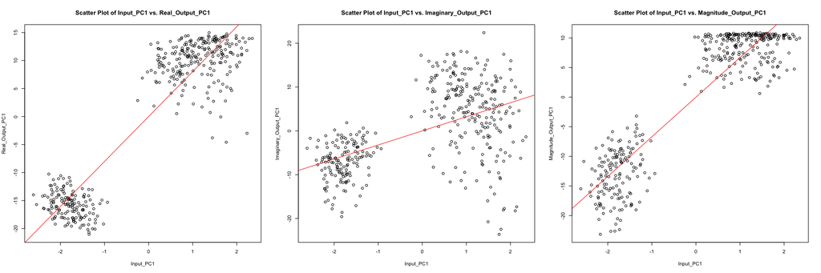

```r
options(repr.plot.width = 18, repr.plot.height = 6)
par(mfrow = c(1, 3))

# Plotting Input_PC1 against Real_Output_PC1
plot(input_scores[, 1], output_scores_real[, 1],
     xlab = "Input_PC1", ylab = "Real_Output_PC1",
     main = "Scatter Plot of Input_PC1 vs. Real_Output_PC1")
abline(lm(output_scores_real[, 1] ~ input_scores[, 1]), col = "red")

# Plotting Input_PC1 against Imaginary_Output_PC1
plot(input_scores[, 1], output_scores_imag[, 1],
     xlab = "Input_PC1", ylab = "Imaginary_Output_PC1",
     main = "Scatter Plot of Input_PC1 vs. Imaginary_Output_PC1")
abline(lm(output_scores_imag[, 1] ~ input_scores[, 1]), col = "red")

# Plotting Input_PC1 against Magnitude_Output_PC1
plot(input_scores[, 1], output_scores_magnitude[, 1],
     xlab = "Input_PC1", ylab = "Magnitude_Output_PC1",
     main = "Scatter Plot of Input_PC1 vs. Magnitude_Output_PC1")
abline(lm(output_scores_magnitude[, 1] ~ input_scores[, 1]), col = "red")
```

So previously correlation matrix suggested:

- Input_PC1 and Real_Output_PC1 have a correlation of 0.92
- Input_PC1 and Imaginary_Output_PC1 have a high correlation of 0.53
- Input_PC1 and Magnitude_Output_PC1 have a high correlation of 0.92

So, the above plots visualizes these results. The slope of the line is steeper for the first and third plots indicating the 0.92 correlation between input data and real_output, magnitude_output. Also, plots for the imaginary_output yields a higher variance and deviation from the line since PC1 for that data is less capable of explaining the variance than the other ones.

### What insights can we draw from the PCA regarding the relationship between geometry and electromagnetic behavior?

We need to determine what are the attributes that most contribute to the PC1 of input_data.

```r
loadings_input <- input_data_pca$rotation

loadings_input_pc1 <- loadings_input[, 1]

sorted_loadings_pc1 <- sort(abs(loadings_input_pc1), decreasing = TRUE)

top_features <- names(sorted_loadings_pc1)[1:5]
print(top_features)
```

```
[1] "width.of.patch"                   "height.of.substrate"
[3] "dielectric.constant.of.substrate" "length.of.patch"
[5] "height.of.patch"
```

The PCA results suggest that the features contributing most to the variance in the data are the **width of the patch**, **height of the substrate**, **dielectric constant of the substrate**, **length of the patch**, and **height of the patch**. These top features are likely influential in shaping the relationship between the geometric properties of the design and its electromagnetic behavior. Therefore, they highlight key dimensions and material properties (like dielectric constant) that impact overall performance. This insight provides an understanding how specific geometric adjustments might alter electromagnetic responses.

# Regression Modelling

First, we need to select for which frequency values we should make predictions for. To do that we can determine the resonance frequencies where magnitude of S11 is the lowest.

### To Find Resonance Frequencies:

With the below command, for each sample the frequency where the lowest magnitude occured is obtained. And then, count of frequency with lowest magnitudes is found. Below "resonance frequencies" shows the top 3 frequency values where the lowest magnitude is obtained more frequently.

```
resonance_frequencies
X200   X0 X114
  77   63    6
```

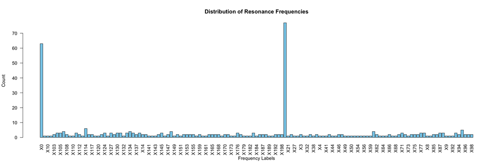

```r
# Find the frequency index where the S11 magnitude is minimum
min_magnitude_indices <- apply(s11_magnitude, 1, which.min)

# Extract the frequencies corresponding to the minimum S11 magnitude for each frequency band
resonance_frequencies <- colnames(s11_magnitude)[min_magnitude_indices]


#print(resonance_frequencies)

# Count the frequency of each resonance frequency
resonance_frequency_count <- table(resonance_frequencies)

#print(resonance_frequency_count)

# Sort the count in descending order and get the top 3
top_3_resonance_frequencies <- sort(resonance_frequency_count, decreasing = TRUE)[1:3]

# Print the top 3 resonance frequencies
print(top_3_resonance_frequencies)

# Plot the distribution of resonance frequencies
barplot(table(resonance_frequencies),
        main = "Distribution of Resonance Frequencies",
        xlab = "Frequency Labels",
        ylab = "Count",
        col = "skyblue",
        las = 2)  # Rotate x-axis labels for readability
```

Therefore, we can conclude that for most of the samples the lowest magnitudes happens for the frequency values of X200, X0, X114.

## Regression Model for Predicting Real Part of Output for the frequency of X200:

```r
# target frequency
target_frequency_200 <- s11_real[,"X200"]

# fit a linear regression model
model_real_X200 <- lm(target_frequency_200 ~ ., data = input_data)

summary(model_real_X200)
```

```
Call:
lm(formula = target_frequency_200 ~ ., data = input_data)

Residuals:
     Min       1Q   Median       3Q      Max
-0.83283 -0.14191 -0.03549  0.11961  1.28410

Coefficients:
                                           Estimate Std. Error t value Pr(>|t|)
(Intercept)                                -1.22270    0.15080  -8.108 7.46e-15
length.of.patch                            -0.01779    0.01485  -1.198 0.231573
width.of.patch                              0.14004    0.03169   4.419 1.30e-05
height.of.patch                             2.56210    1.61881   1.583 0.114335
height.of.substrate                         1.51782    0.13793  11.004  < 2e-16
height.of.solder.resist.layer               0.57087    0.59652   0.957 0.339182
radius.of.the.probe                        -5.03994    1.36804  -3.684 0.000264
c_pad                                       1.21595    1.98866   0.611 0.541279
c_antipad                                  -0.27604    0.66417  -0.416 0.677923
c_probe                                    -0.22811    0.12856  -1.774 0.076834
dielectric.constant.of.substrate            0.02309    0.01874   1.233 0.218475
dielectric.constant.of.solder.resist.layer  0.02261    0.01633   1.384 0.167046

(Intercept)                                ***
length.of.patch
width.of.patch                             ***
height.of.patch
height.of.substrate                        ***
height.of.solder.resist.layer
radius.of.the.probe                        ***
c_pad
c_antipad
c_probe                                    .
dielectric.constant.of.substrate
dielectric.constant.of.solder.resist.layer
---
Signif. codes:  0 ‘***’ 0.001 ‘**’ 0.01 ‘*’ 0.05 ‘.’ 0.1 ‘ ’ 1

Residual standard error: 0.2758 on 373 degrees of freedom
Multiple R-squared:  0.8223,	Adjusted R-squared:  0.8171
F-statistic: 156.9 on 11 and 373 DF,  p-value: < 2.2e-16
```

The above regression model explains approximately 82% of the variance in the dependent variable, as indicated by the multiple R-squared value of 0.8223 (adjusted R-squared: 0.8171). This high R-squared suggests a strong fit to the data. The residual standard error of 0.2758 is relatively low. The model’s F-statistic of 156.9, with a very small p-value (< 2.2e-16), shows that the overall model is statistically significant.

## Regression Model for Predicting Imaginary Part of Output for the frequency of X200:

```r
# target frequency
target_frequency_200_imag <- s11_imag[,"X200"]

# fit a linear regression model
model_imag_X200 <- lm(target_frequency_200_imag ~ ., data = input_data)

summary(model_imag_X200)
```

```
Call:
lm(formula = target_frequency_200_imag ~ ., data = input_data)

Residuals:
     Min       1Q   Median       3Q      Max
-1.06084 -0.12455  0.04344  0.17488  0.63151

Coefficients:
                                            Estimate Std. Error t value
(Intercept)                                 0.748607   0.154065   4.859
length.of.patch                            -0.006635   0.015170  -0.437
width.of.patch                              0.055352   0.032377   1.710
height.of.patch                             1.790772   1.653904   1.083
height.of.substrate                        -0.869513   0.140922  -6.170
height.of.solder.resist.layer              -0.187489   0.609451  -0.308
radius.of.the.probe                        -4.926878   1.397706  -3.525
c_pad                                       1.493068   2.031777   0.735
c_antipad                                   1.037106   0.678567   1.528
c_probe                                    -0.623074   0.131351  -4.744
dielectric.constant.of.substrate            0.013695   0.019141   0.715
dielectric.constant.of.solder.resist.layer -0.017135   0.016683  -1.027
                                           Pr(>|t|)
(Intercept)                                1.74e-06 ***
length.of.patch                            0.662084
width.of.patch                             0.088169 .
height.of.patch                            0.279617
height.of.substrate                        1.78e-09 ***
height.of.solder.resist.layer              0.758531
radius.of.the.probe                        0.000476 ***
c_pad                                      0.462888
c_antipad                                  0.127267
c_probe                                    3.00e-06 ***
dielectric.constant.of.substrate           0.474753
dielectric.constant.of.solder.resist.layer 0.305050
---
Signif. codes:  0 ‘***’ 0.001 ‘**’ 0.01 ‘*’ 0.05 ‘.’ 0.1 ‘ ’ 1

Residual standard error: 0.2818 on 373 degrees of freedom
Multiple R-squared:  0.3426,	Adjusted R-squared:  0.3232
F-statistic: 17.67 on 11 and 373 DF,  p-value: < 2.2e-16
```

This model explains about 34% of the variance in the dependent variable, as shown by the multiple R-squared value of 0.3426. This R-squared value indicates a moderate fit to the data asexpected due to low PC1 value of the imaginary part.

Looking at the predictor variables' p-values, some are significant. Height of substrate, radius of the probe, and c_probe are statistically significant (p < 0.05) and may meaningfully contribute to the model. The overall F-statistic of 17.67 with a p-value < 2.2e-16 confirms that the model is statistically significant, but not all predictors are likely essential in explaining the variation in the dependent variable.

## Regression Model for Predicting Magnitude of Output for the frequency of X200:

```r
# target frequency
target_frequency_200_magnitude <- s11_magnitude[,"X200"]

# fit a linear regression model
model_magnitude_X200 <- lm(target_frequency_200_magnitude ~ ., data = input_data)

summary(model_magnitude_X200)
```

```
Call:
lm(formula = target_frequency_200_magnitude ~ ., data = input_data)

Residuals:
     Min       1Q   Median       3Q      Max
-0.64084 -0.02946  0.03203  0.07386  0.24640

Coefficients:
                                             Estimate Std. Error t value
(Intercept)                                 1.1967816  0.0793954  15.074
length.of.patch                            -0.0245858  0.0078177  -3.145
width.of.patch                             -0.0476617  0.0166849  -2.857
height.of.patch                             1.0123338  0.8523165   1.188
height.of.substrate                        -0.2935679  0.0726223  -4.042
height.of.solder.resist.layer               0.1476055  0.3140722   0.470
radius.of.the.probe                        -1.5726844  0.7202885  -2.183
c_pad                                       0.9066674  1.0470484   0.866
c_antipad                                   0.0920968  0.3496902   0.263
c_probe                                    -0.0922338  0.0676902  -1.363
dielectric.constant.of.substrate           -0.0008801  0.0098642  -0.089
dielectric.constant.of.solder.resist.layer  0.0087125  0.0085973   1.013
                                           Pr(>|t|)
(Intercept)                                 < 2e-16 ***
length.of.patch                             0.00179 **
width.of.patch                              0.00452 **
height.of.patch                             0.23569
height.of.substrate                        6.43e-05 ***
height.of.solder.resist.layer               0.63865
radius.of.the.probe                         0.02963 *
c_pad                                       0.38709
c_antipad                                   0.79241
c_probe                                     0.17383
dielectric.constant.of.substrate            0.92896
dielectric.constant.of.solder.resist.layer  0.31152
---
Signif. codes:  0 ‘***’ 0.001 ‘**’ 0.01 ‘*’ 0.05 ‘.’ 0.1 ‘ ’ 1

Residual standard error: 0.1452 on 373 degrees of freedom
Multiple R-squared:  0.4766,	Adjusted R-squared:  0.4612
F-statistic: 30.88 on 11 and 373 DF,  p-value: < 2.2e-16
```

This model explains about 48% of the variance in the dependent variable, as PC1 suggested. The residual standard error of 0.1452 shows the average deviation of predictions from actual value is less than previous models.

Several predictors are statistically significant: length and width of the patch, height of substrate, and radius of the probe.

## Plots for Predictions vs Actual Values for All Models

```r
# generate predictions for real part of output for frequency X200
predicted_values <- predict(model_real_X200, newdata = input_data)

# data frame with actual and predicted values
comparison_data <- data.frame(
  Actual = target_frequency_200,
  Predicted = predicted_values
)

# plot Predicted vs Actual
real200 <- ggplot(comparison_data, aes(x = Actual, y = Predicted)) +
  geom_point(color = "blue") +
  geom_abline(slope = 1, intercept = 0, color = "red", linetype = "dashed") +
  labs(
    title = "Predicted vs Actual Values for S11 Real Part at Frequency X200",
    x = "Actual Values",
    y = "Predicted Values"
  ) +
  theme_minimal()



# generate predictions for imaginary part of output for frequency X200
predicted_values <- predict(model_imag_X200, newdata = input_data)

# data frame with actual and predicted values
comparison_data <- data.frame(
  Actual = target_frequency_200_imag,
  Predicted = predicted_values
)

# plot Predicted vs Actual
imag200 <- ggplot(comparison_data, aes(x = Actual, y = Predicted)) +
  geom_point(color = "blue") +
  geom_abline(slope = 1, intercept = 0, color = "red", linetype = "dashed") +
  labs(
    title = "Predicted vs Actual Values for S11 Imaginary Part at Frequency X200",
    x = "Actual Values",
    y = "Predicted Values"
  ) +
  theme_minimal()




# generate predictions for magnitude of output for frequency X200
predicted_values <- predict(model_magnitude_X200, newdata = input_data)

# data frame with actual and predicted values
comparison_data <- data.frame(
  Actual = target_frequency_200_magnitude,
  Predicted = predicted_values
)

# plot Predicted vs Actual
magnitude200 <- ggplot(comparison_data, aes(x = Actual, y = Predicted)) +
  geom_point(color = "blue") +
  geom_abline(slope = 1, intercept = 0, color = "red", linetype = "dashed") +
  labs(
    title = "Predicted vs Actual Values for S11 Magnitude at Frequency X200",
    x = "Actual Values",
    y = "Predicted Values"
  ) +
  theme_minimal()
```

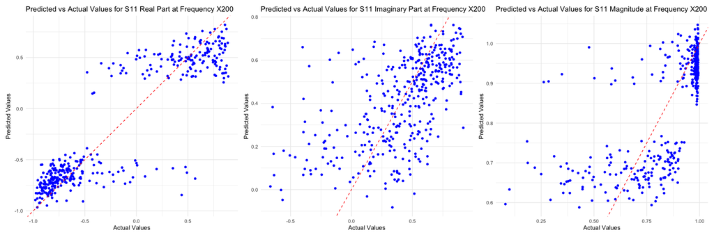

```r
options(repr.plot.width = 18, repr.plot.height = 6)
real200 + imag200 + magnitude200 + plot_layout(ncol = 3)
```

The above plots show that:

## - Actual values vs Predicted values vary most for the imaginary part of the model

## Regression Model for Predicting Real Part of Output for the frequency of X0:

```r
# target frequency
target_frequency_0 <- s11_real[,"X0"]

# fit a linear regression model
model_real_X0 <- lm(target_frequency_0 ~ ., data = input_data)

summary(model_real_X0)
```

```
Call:
lm(formula = target_frequency_0 ~ ., data = input_data)

Residuals:
     Min       1Q   Median       3Q      Max
-0.73647 -0.16221 -0.06812  0.07867  1.65665

Coefficients:
                                            Estimate Std. Error t value
(Intercept)                                -0.887602   0.163054  -5.444
length.of.patch                            -0.035371   0.016055  -2.203
width.of.patch                              0.051896   0.034266   1.515
height.of.patch                            -1.677240   1.750403  -0.958
height.of.substrate                         2.398130   0.149144  16.079
height.of.solder.resist.layer              -0.748170   0.645010  -1.160
radius.of.the.probe                        -1.594848   1.479257  -1.078
c_pad                                      -2.798118   2.150323  -1.301
c_antipad                                  -1.804921   0.718159  -2.513
c_probe                                     0.434844   0.139015   3.128
dielectric.constant.of.substrate            0.008905   0.020258   0.440
dielectric.constant.of.solder.resist.layer -0.012047   0.017656  -0.682
                                           Pr(>|t|)
(Intercept)                                9.48e-08 ***
length.of.patch                              0.0282 *
width.of.patch                               0.1307
height.of.patch                              0.3386
height.of.substrate                         < 2e-16 ***
height.of.solder.resist.layer                0.2468
radius.of.the.probe                          0.2817
c_pad                                        0.1940
c_antipad                                    0.0124 *
c_probe                                      0.0019 **
dielectric.constant.of.substrate             0.6605
dielectric.constant.of.solder.resist.layer   0.4955
---
Signif. codes:  0 ‘***’ 0.001 ‘**’ 0.01 ‘*’ 0.05 ‘.’ 0.1 ‘ ’ 1

Residual standard error: 0.2983 on 373 degrees of freedom
Multiple R-squared:  0.8582,	Adjusted R-squared:  0.8541
F-statistic: 205.3 on 11 and 373 DF,  p-value: < 2.2e-16
```

The above model, with an adjusted R-squared of 0.8541, explains approximately 86% of the variance in the response variable, indicating a very strong fit. Key predictors include height of substrate, length of patch, antipad, and probe capacitance.

To compare with the regression model of predicting real part of the data for the frequency X200:

- The model with frequency X200 has a slightly lower adjusted R-squared of 0.8171, explaining around 82% of the variance in the response variable—still a strong fit, but slightly less robust than the model with frequency X0.
- Both models are statistically significant with p-value < 2.2e-16

## Regression Model for Predicting Imaginary Part of Output for the frequency of X0:

```r
# target frequency
target_frequency_0_imag <- s11_imag[,"X0"]

# fit a linear regression model
model_imag_X0 <- lm(target_frequency_0_imag ~ ., data = input_data)

summary(model_imag_X0)
```

```
Call:
lm(formula = target_frequency_0_imag ~ ., data = input_data)

Residuals:
     Min       1Q   Median       3Q      Max
-0.92899 -0.15765  0.05639  0.18335  0.81818

Coefficients:
                                            Estimate Std. Error t value
(Intercept)                                 0.141878   0.173274   0.819
length.of.patch                            -0.009983   0.017061  -0.585
width.of.patch                              0.207488   0.036414   5.698
height.of.patch                             2.424461   1.860113   1.303
height.of.substrate                        -0.809398   0.158492  -5.107
height.of.solder.resist.layer              -0.548936   0.685438  -0.801
radius.of.the.probe                        -5.659808   1.571972  -3.600
c_pad                                      -1.518902   2.285100  -0.665
c_antipad                                  -0.240234   0.763171  -0.315
c_probe                                    -0.322765   0.147728  -2.185
dielectric.constant.of.substrate           -0.018499   0.021528  -0.859
dielectric.constant.of.solder.resist.layer  0.018615   0.018763   0.992
                                           Pr(>|t|)
(Intercept)                                0.413420
length.of.patch                            0.558822
width.of.patch                             2.46e-08 ***
height.of.patch                            0.193244
height.of.substrate                        5.24e-07 ***
height.of.solder.resist.layer              0.423726
radius.of.the.probe                        0.000361 ***
c_pad                                      0.506654
c_antipad                                  0.753102
c_probe                                    0.029521 *
dielectric.constant.of.substrate           0.390720
dielectric.constant.of.solder.resist.layer 0.321786
---
Signif. codes:  0 ‘***’ 0.001 ‘**’ 0.01 ‘*’ 0.05 ‘.’ 0.1 ‘ ’ 1

Residual standard error: 0.317 on 373 degrees of freedom
Multiple R-squared:  0.1344,	Adjusted R-squared:  0.1089
F-statistic: 5.265 on 11 and 373 DF,  p-value: 9.649e-08
```

This model has a relatively low adjusted R-squared of 0.1089, indicating that it explains only about 11% of the variance in the response variable. The model’s residual standard error is 0.317, meaning that the model’s predictions have a notable average deviation from actual values. With a low F-statistic (5.265) and overall p-value of 9.649e-08, the model is statistically significant but lacks substantial explanatory power compared to stronger models. This suggests that this model may not adequately capture the complexity of the data, and other variables or transformations might be needed for improved prediction.

## Regression Model for Predicting Magnitude of Output for the frequency of X0:

```r
# target frequency
target_frequency_0_magnitude <- s11_magnitude[,"X0"]

# fit a linear regression model
model_magnitude_X0 <- lm(target_frequency_0_magnitude ~ ., data = input_data)


summary(model_magnitude_X0)
```

```
Call:
lm(formula = target_frequency_0_magnitude ~ ., data = input_data)

Residuals:
     Min       1Q   Median       3Q      Max
-0.59802 -0.01151  0.01978  0.04669  0.12909

Coefficients:
                                            Estimate Std. Error t value
(Intercept)                                 0.994893   0.053810  18.489
length.of.patch                             0.013319   0.005298   2.514
width.of.patch                              0.006066   0.011308   0.536
height.of.patch                            -0.247392   0.577657  -0.428
height.of.substrate                        -0.245622   0.049220  -4.990
height.of.solder.resist.layer               0.049796   0.212862   0.234
radius.of.the.probe                        -0.367089   0.488175  -0.752
c_pad                                       0.398833   0.709637   0.562
c_antipad                                   0.292366   0.237002   1.234
c_probe                                    -0.114194   0.045877  -2.489
dielectric.constant.of.substrate           -0.013396   0.006685  -2.004
dielectric.constant.of.solder.resist.layer -0.000804   0.005827  -0.138
                                           Pr(>|t|)
(Intercept)                                 < 2e-16 ***
length.of.patch                              0.0124 *
width.of.patch                               0.5920
height.of.patch                              0.6687
height.of.substrate                        9.26e-07 ***
height.of.solder.resist.layer                0.8152
radius.of.the.probe                          0.4525
c_pad                                        0.5744
c_antipad                                    0.2181
c_probe                                      0.0132 *
dielectric.constant.of.substrate             0.0458 *
dielectric.constant.of.solder.resist.layer   0.8903
---
Signif. codes:  0 ‘***’ 0.001 ‘**’ 0.01 ‘*’ 0.05 ‘.’ 0.1 ‘ ’ 1

Residual standard error: 0.09843 on 373 degrees of freedom
Multiple R-squared:  0.3489,	Adjusted R-squared:  0.3297
F-statistic: 18.17 on 11 and 373 DF,  p-value: < 2.2e-16
```

The above model has a residual standard error of 0.09843 and an adjusted R-squared of 0.3297, meaning it explains about 33% of the variance in the data.

In comparison, the model that predicts magnitude of output for frequency of X200 has a slightly higher residual standard error (0.1452) but a higher adjusted R-squared of 0.4612, explaining about 46% of the variance. That model has a stronger overall F-statistic (30.88), indicating it fits the data more effectively than this model.

In summary:

- The model with X0 frequency has a lower residual error, suggesting better fit precision, but a lower R-squared, indicating it explains less variance.
- The model with X200 frequency, with a higher R-squared and more significant predictors, provides a better overall explanatory power and a stronger fit to the data.

## Plots for Predictions vs Actual Values for All Models

```r
# generate predictions for real part of output for frequency X200
predicted_values <- predict(model_real_X0, newdata = input_data)

# data frame with actual and predicted values
comparison_data <- data.frame(
  Actual = target_frequency_0,
  Predicted = predicted_values
)

# plot Predicted vs Actual
real0 <- ggplot(comparison_data, aes(x = Actual, y = Predicted)) +
  geom_point(color = "blue") +
  geom_abline(slope = 1, intercept = 0, color = "red", linetype = "dashed") +
  labs(
    title = "Predicted vs Actual Values for S11 Real Part at Frequency X0",
    x = "Actual Values",
    y = "Predicted Values"
  ) +
  theme_minimal()


# generate predictions for imaginary part of output for frequency X200
predicted_values <- predict(model_imag_X0, newdata = input_data)

# data frame with actual and predicted values
comparison_data <- data.frame(
  Actual = target_frequency_0_imag,
  Predicted = predicted_values
)

# plot Predicted vs Actual
imag0 <- ggplot(comparison_data, aes(x = Actual, y = Predicted)) +
  geom_point(color = "blue") +
  geom_abline(slope = 1, intercept = 0, color = "red", linetype = "dashed") +
  labs(
    title = "Predicted vs Actual Values for S11 Imaginary Part at Frequency X0",
    x = "Actual Values",
    y = "Predicted Values"
  ) +
  theme_minimal()


# generate predictions for magnitude of output for frequency X200
predicted_values <- predict(model_magnitude_X0, newdata = input_data)

# data frame with actual and predicted values
comparison_data <- data.frame(
  Actual = target_frequency_0_magnitude,
  Predicted = predicted_values
)

# plot Predicted vs Actual
magnitude0 <- ggplot(comparison_data, aes(x = Actual, y = Predicted)) +
  geom_point(color = "blue") +
  geom_abline(slope = 1, intercept = 0, color = "red", linetype = "dashed") +
  labs(
    title = "Predicted vs Actual Values for S11 Magnitude at Frequency X0",
    x = "Actual Values",
    y = "Predicted Values"
  ) +
  theme_minimal()
```

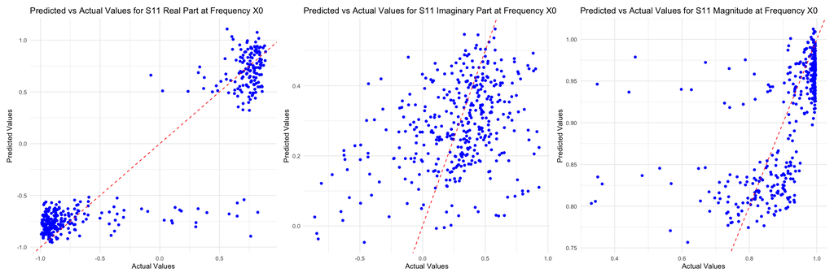

```r
options(repr.plot.width = 18, repr.plot.height = 6)

real0 + imag0 + magnitude0 + plot_layout(ncol = 3)
```

The plots above show that:

- The predicted values show the greatest variation from the actual values for the model with the imaginary outcomes, suggesting a less accurate fit in this part of the model.
- For the model with real outcomes, the data appears to form two distinct clusters, indicating denser data behavior and suggesting stronger performance and a better fit for the regression model in this component.

## Regression Model for Predicting Real Part of Output for the frequency of X114:

```r
# target frequency
target_frequency_114 <- s11_real[,"X114"]

# fit a linear regression model
model_real_X114 <- lm(target_frequency_114 ~ ., data = input_data)

summary(model_real_X114)
```

```
Call:
lm(formula = target_frequency_114 ~ ., data = input_data)

Residuals:
     Min       1Q   Median       3Q      Max
-0.62159 -0.17557 -0.04896  0.12943  1.58211

Coefficients:
                                            Estimate Std. Error t value
(Intercept)                                -1.445625   0.164440  -8.791
length.of.patch                             0.034466   0.016192   2.129
width.of.patch                              0.104958   0.034557   3.037
height.of.patch                            -0.330368   1.765279  -0.187
height.of.substrate                         1.618066   0.150412  10.758
height.of.solder.resist.layer               0.571903   0.650492   0.879
radius.of.the.probe                        -3.104198   1.491828  -2.081
c_pad                                       0.111999   2.168599   0.052
c_antipad                                  -0.250561   0.724262  -0.346
c_probe                                     0.301286   0.140197   2.149
dielectric.constant.of.substrate            0.003899   0.020430   0.191
dielectric.constant.of.solder.resist.layer  0.024940   0.017806   1.401
                                           Pr(>|t|)
(Intercept)                                 < 2e-16 ***
length.of.patch                             0.03394 *
width.of.patch                              0.00256 **
height.of.patch                             0.85165
height.of.substrate                         < 2e-16 ***
height.of.solder.resist.layer               0.37987
radius.of.the.probe                         0.03813 *
c_pad                                       0.95884
c_antipad                                   0.72957
c_probe                                     0.03228 *
dielectric.constant.of.substrate            0.84874
dielectric.constant.of.solder.resist.layer  0.16216
---
Signif. codes:  0 ‘***’ 0.001 ‘**’ 0.01 ‘*’ 0.05 ‘.’ 0.1 ‘ ’ 1

Residual standard error: 0.3008 on 373 degrees of freedom
Multiple R-squared:  0.7818,	Adjusted R-squared:  0.7754
F-statistic: 121.5 on 11 and 373 DF,  p-value: < 2.2e-16
```

This model has a residual standard error of 0.3008, indicating how closely the predicted values align with actual values, representing better fit. The Multiple R-squared is 0.7818, showing that around 78% of the variability in the response variable is explained by the model indicates a strong explanatory power.

Comparison:

- The model with frequency of X200 with a Residual Standard Error of 0.2758 has a higher R-squared (0.8223) and Adjusted R-squared (0.8171), suggesting it explains more variance in the response variable and has a slightly better fit.
- Another model with frequency of X0 with a Residual Standard Error of 0.2983 achieves the best explanatory power with R-squared of 0.8582 and Adjusted R-squared of 0.8541, indicating it is the strongest model in terms of predictive accuracy and fit among the three.

In summary, the fit of the models vary slightly according to the frequency attribute of the outcome. But still all three of the models predicting the **REAL PART** of the outcomes performs a good fit.

## Regression Model for Predicting Imaginary Part of Output for the frequency of X114:

```r
# target frequency
target_frequency_114_imag <- s11_imag[,"X114"]

# fit a linear regression model
model_imag_X114 <- lm(target_frequency_114_imag ~ ., data = input_data)

summary(model_imag_X114)
```

```
Call:
lm(formula = target_frequency_114_imag ~ ., data = input_data)

Residuals:
     Min       1Q   Median       3Q      Max
-1.02556 -0.15640  0.03037  0.17516  0.79476

Coefficients:
                                            Estimate Std. Error t value
(Intercept)                                -0.029081   0.155659  -0.187
length.of.patch                             0.036456   0.015327   2.379
width.of.patch                              0.112823   0.032712   3.449
height.of.patch                             2.562547   1.671015   1.534
height.of.substrate                        -1.089572   0.142380  -7.653
height.of.solder.resist.layer               0.841614   0.615756   1.367
radius.of.the.probe                        -3.489032   1.412166  -2.471
c_pad                                       0.290612   2.052798   0.142
c_antipad                                   1.555850   0.685588   2.269
c_probe                                    -0.799073   0.132710  -6.021
dielectric.constant.of.substrate            0.085533   0.019339   4.423
dielectric.constant.of.solder.resist.layer -0.006921   0.016855  -0.411
                                           Pr(>|t|)
(Intercept)                                0.851900
length.of.patch                            0.017883 *
width.of.patch                             0.000627 ***
height.of.patch                            0.125994
height.of.substrate                        1.70e-13 ***
height.of.solder.resist.layer              0.172512
radius.of.the.probe                        0.013931 *
c_pad                                      0.887497
c_antipad                                  0.023816 *
c_probe                                    4.15e-09 ***
dielectric.constant.of.substrate           1.28e-05 ***
dielectric.constant.of.solder.resist.layer 0.681582
---
Signif. codes:  0 ‘***’ 0.001 ‘**’ 0.01 ‘*’ 0.05 ‘.’ 0.1 ‘ ’ 1

Residual standard error: 0.2847 on 373 degrees of freedom
Multiple R-squared:  0.3411,	Adjusted R-squared:  0.3217
F-statistic: 17.56 on 11 and 373 DF,  p-value: < 2.2e-16
```

For the above model the Residual Standard Error is 0.2847, and the Multiple R-squared is 0.3411, with an Adjusted R-squared of 0.3217, indicating that this model explains about 32% of the variability in the response.

Comparison:

- Another model of predicting outcome for frequency of X200 with a Residual Standard Error of 0.2818 and a slightly higher R-squared of 0.3426 shows a marginally better fit.
- The other model with frequency X0 has a higher Residual Standard Error (0.317) and lower R-squared (0.1344), indicating it explains less of the variance in the response and is likely a less effective model for prediction.

In summary, the fit of the models vary slightly according to the frequency attribute of the outcome. But all three of the models cannot perform as good as the ones that predicts the real part of the data. This situaiton can be also expected by looking at how much variance that PC1s explain for imaginary parts of the data.

## Regression Model for Predicting Magnitude of Output for the frequency of X114:

```r
# target frequency
target_frequency_114_magnitude <- s11_magnitude[,"X114"]

# fit a linear regression model
model_magnitude_X114 <- lm(target_frequency_114_magnitude ~ ., data = input_data)

summary(model_magnitude_X114)
```

```
Call:
lm(formula = target_frequency_114_magnitude ~ ., data = input_data)

Residuals:
     Min       1Q   Median       3Q      Max
-0.79194 -0.03156  0.02270  0.07085  0.35074

Coefficients:
                                            Estimate Std. Error t value
(Intercept)                                 0.964273   0.082878  11.635
length.of.patch                             0.023121   0.008161   2.833
width.of.patch                             -0.032901   0.017417  -1.889
height.of.patch                             0.097809   0.889707   0.110
height.of.substrate                        -0.557744   0.075808  -7.357
height.of.solder.resist.layer               0.081793   0.327850   0.249
radius.of.the.probe                         0.444113   0.751887   0.591
c_pad                                       0.447801   1.092982   0.410
c_antipad                                   0.432906   0.365031   1.186
c_probe                                     0.019663   0.070660   0.278
dielectric.constant.of.substrate            0.024111   0.010297   2.342
dielectric.constant.of.solder.resist.layer -0.021316   0.008974  -2.375
                                           Pr(>|t|)
(Intercept)                                 < 2e-16 ***
length.of.patch                             0.00486 **
width.of.patch                              0.05966 .
height.of.patch                             0.91252
height.of.substrate                         1.2e-12 ***
height.of.solder.resist.layer               0.80313
radius.of.the.probe                         0.55510
c_pad                                       0.68226
c_antipad                                   0.23640
c_probe                                     0.78095
dielectric.constant.of.substrate            0.01973 *
dielectric.constant.of.solder.resist.layer  0.01805 *
---
Signif. codes:  0 ‘***’ 0.001 ‘**’ 0.01 ‘*’ 0.05 ‘.’ 0.1 ‘ ’ 1

Residual standard error: 0.1516 on 373 degrees of freedom
Multiple R-squared:  0.6034,	Adjusted R-squared:  0.5917
F-statistic: 51.59 on 11 and 373 DF,  p-value: < 2.2e-16
```

The model has a Residual Standard Error of 0.1516 and a Multiple R-squared of 0.6034, indicating that it explains approximately 60% of the variance in the response.

Comparison:

- Another model predicting output with frequency of X0 shows a lower Residual Standard Error (0.09843) and lower R-squared (0.3489), explaining less of the variance.
- The other model predicting output with frequencyo f X200 has Residual Standard Error of 0.1452 and R-squared of 0.4766 has a moderate fit but performs better than the one with frequency of X0.

Overall, this model here has the best fit, explaining more variance than the other two. However, in general all three has a moderate fit explaining the data.

## Plots for Predictions vs Actual Values for All Models

```r
# generate predictions for real part of output for frequency X114
predicted_values <- predict(model_real_X114, newdata = input_data)

# data frame with actual and predicted values
comparison_data <- data.frame(
  Actual = target_frequency_114,
  Predicted = predicted_values
)

# plot Predicted vs Actual
real114 <- ggplot(comparison_data, aes(x = Actual, y = Predicted)) +
  geom_point(color = "blue") +
  geom_abline(slope = 1, intercept = 0, color = "red", linetype = "dashed") +
  labs(
    title = "Predicted vs Actual Values for S11 Real Part at Frequency X114",
    x = "Actual Values",
    y = "Predicted Values"
  ) +
  theme_minimal()


# generate predictions for imaginary part of output for frequency X114
predicted_values <- predict(model_imag_X114, newdata = input_data)

# data frame with actual and predicted values
comparison_data <- data.frame(
  Actual = target_frequency_114_imag,
  Predicted = predicted_values
)

# plot Predicted vs Actual
imag114 <- ggplot(comparison_data, aes(x = Actual, y = Predicted)) +
  geom_point(color = "blue") +
  geom_abline(slope = 1, intercept = 0, color = "red", linetype = "dashed") +
  labs(
    title = "Predicted vs Actual Values for S11 Imaginary Part at Frequency X114",
    x = "Actual Values",
    y = "Predicted Values"
  ) +
  theme_minimal()


# generate predictions for magnitude of output for frequency X114
predicted_values <- predict(model_magnitude_X114, newdata = input_data)

# data frame with actual and predicted values
comparison_data <- data.frame(
  Actual = target_frequency_114_magnitude,
  Predicted = predicted_values
)

# plot Predicted vs Actual
magnitude114 <- ggplot(comparison_data, aes(x = Actual, y = Predicted)) +
  geom_point(color = "blue") +
  geom_abline(slope = 1, intercept = 0, color = "red", linetype = "dashed") +
  labs(
    title = "Predicted vs Actual Values for S11 Magnitude at Frequency X114",
    x = "Actual Values",
    y = "Predicted Values"
  ) +
  theme_minimal()
```

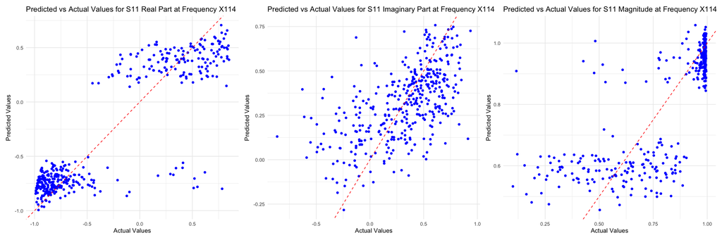

```r
options(repr.plot.width = 18, repr.plot.height = 6)

real114 + imag114 + magnitude114 + plot_layout(ncol = 3)
```

The behavior of plots similar to the previous ones. The plots again show that there is a high variance between prediction and actual values for the model predicting imaginary part of the data.

And the model predicting the real part of the data seems to have the best fit.

# Model Performance and Interpretability

**Model Performance and Interpretability**

1. **PCA vs. Regression Models for Simplifying and Predicting Performance**
   - **PCA** helps reduce the complexity of the data by identifying the principal components, which capture the most variance with fewer features. In the context of antenna performance, PCA can simplify complex datasets involving multiple geometric and material parameters, allowing us to work with fewer components that still capture the majority of the data’s information.
   - **Regression Models** take this simplification further by mapping the reduced-dimensional data directly to the antenna performance metrics, like gain, bandwidth, or efficiency. Regression models, especially if linear, can offer interpretable relationships by showing how each principal component or feature impacts the performance metric. However, they may fall short in capturing non-linear interactions, which are often inherent in electromagnetic behavior.
2. **Potential Limitations and Improvements**
   - **Limitations**:
     - **PCA assumes linear relationships** among features, which may oversimplify the data, missing out on crucial non-linear interactions between geometry and electromagnetic properties.
     - **Linear regression models** based on principal components may not fully capture complex, non-linear behaviors typical in antenna performance, especially under varying environmental conditions or material properties.
   - **Improvements**:
     - **Non-linear dimensionality reduction techniques**, like kernel PCA, could capture more complex relationships.
     - **Non-linear regression methods**, such as polynomial regression, random forests, or neural networks, may improve predictive accuracy by modeling interactions that linear models miss.

Using these methods to enhance PCA and regression models could yield a better balance between interpretability and the ability to capture the nuanced, non-linear aspects of antenna performance.